# **Questions Pair DataSet**

**Quora** is an American question-and-answer website where questions are asked, answered, followed, and edited by Internet users, either factually or in the form of opinions.

The company was founded in June 2009, and the website was made available to the public for the first time on June 21, 2010. Users can collaborate by editing questions and suggesting edits to answers that have been submitted by other users.

In 2019, the website was visited by 300 million unique people a month

### The task is related to the problem of identifying *duplicate questions.*

### **Problem Statement**

- Identify the questions on Quora that are duplicates of questions that have been asked before.
- This could save efforts and user experience as Quora being a large community can instantly match and provide answers if questions asked are similar.
- We are having the problem of binary classification by predicting whether a pair of questions are duplicates or not.

#### Main Aim to the problem are :

- To Indentify accurately that 2 questions are same as mis-classification would lead to mis trust.
- We need to figure out what probability can be chosen as a threshold inorder to solve the problem accurately.
- The algorithm can be time heavy like can have a latency.
- The problem should not act as a blackbox rather be interpretable.

## DATA

### 1. Overview

There are over 400,000 lines of potential question duplicate pairs. Each line contains `IDs` for each question in the pair, the `full text for each question`, and a `binary value` that indicates whether the line truly contains a `duplicate pair`.

[figure not shown]

### 2. Performance Metrics

Will imply metrics:

- Log-Loss
- Binary Confusion Matrix

### 3. Train and Test Data

We split data on the basis on the ratio of 70:30 . Better would be to split data accross timestamp. As this would help us test on the current trend of question before deployment.

# 1). Exploratory Data Analysis

```python
#importing Libraries

import numpy as np
# Powerful n-dimensional arrays. Numerical computing tools
import pandas as pd
# is a fast, powerful, flexible and easy to use open source data analysis and manipulation tool
import seaborn as sns
# Seaborn is a Python data visualization library based on matplotlib.
import matplotlib.pyplot as plt
# Matplotlib is a comprehensive library for creating static, animated, and interactive visualizations in Python
from subprocess import check_output
# The subprocess is used to run new applications or programs through Python code by creating new processes.
# It also helps to obtain the input/output/error pipes as well as the exit codes of various commands
%matplotlib inline
#With this backend, the output of plotting commands is displayed inline within frontends
#like the Jupyter notebook
import plotly.offline as py
#plotly enables Python users to create beautiful interactive web-based visualizations
py.init_notebook_mode(connected=True)
#to plot plotply ..
import plotly.graph_objs as go
import plotly.tools as tls
import os
#It imports the OS library, which is mainly useful to do OS stuff (bet that was really helpful to you!)
#OS stuff includes: showing the absolute path of a file
import gc
#Python's garbage collector runs during program execution and is triggered when an object's reference count reaches zero.
import re
#a regular expression is denoted as RE
from nltk.corpus import stopwords
# stopwords
#NLTK is a leading platform for building Python programs to work with human language data.
import distance
from nltk.stem import PorterStemmer
#The Porter stemming algorithm (or 'Porter stemmer') is a process for removing the commoner morphological
#and inflexional endings from words in English
from bs4 import BeautifulSoup
#Beautiful Soup is a Python library for pulling data out of HTML and XML files.
from fuzzywuzzy import fuzz
from sklearn.manifold import TSNE
# Import the Required lib packages for WORD-Cloud generation
# https://stackoverflow.com/questions/45625434/how-to-install-wordcloud-in-python3-6
from wordcloud import WordCloud, STOPWORDS
from os import path
from PIL import Image
```

```python
#Read the data set using pandas
df = pd.read_csv("minor/DataSet/Quora.csv")

#printing number of data point
print("Number of Total Data Points : ",df.shape[0])

#Giving insight of a data
df.head()
```

```
Number of Total Data Points :  404290
```

|  | id | qid1 | qid2 | question1 | question2 | is_duplicate |
| --- | --- | --- | --- | --- | --- | --- |
| 0 | 0 | 1 | 2 | What is the step by step guide to invest in sh... | What is the step by step guide to invest in sh... | 0 |
| 1 | 1 | 3 | 4 | What is the story of Kohinoor (Koh-i-Noor) Dia... | What would happen if the Indian government sto... | 0 |
| 2 | 2 | 5 | 6 | How can I increase the speed of my internet co... | How can Internet speed be increased by hacking... | 0 |
| 3 | 3 | 7 | 8 | Why am I mentally very lonely? How can I solve... | Find the remainder when [math]23^{24}[/math] i... | 0 |
| 4 | 4 | 9 | 10 | Which one dissolve in water quikly sugar, salt... | Which fish would survive in salt water? | 0 |

```python
df.info()
```

```
<class 'pandas.core.frame.DataFrame'>
RangeIndex: 404290 entries, 0 to 404289
Data columns (total 6 columns):
id              404290 non-null int64
qid1            404290 non-null int64
qid2            404290 non-null int64
question1       404289 non-null object
question2       404288 non-null object
is_duplicate    404290 non-null int64
dtypes: int64(4), object(2)
memory usage: 18.5+ MB
```

# Overview of Data

```
Unique number of questions are : 537933
Unique Questions that are repeated number of questions are :  20.77953945937505
The most repeated question occurs: 157
```

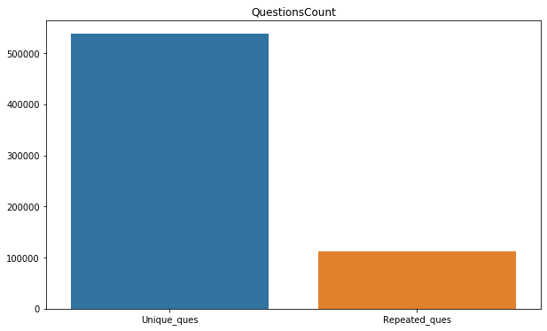

```python
# Checking number of unique questions
Allques = pd.Series(df['qid1'].tolist() + df['qid2'].tolist())

## unique questions
Unique_ques = len(np.unique(Allques))
print("Unique number of questions are : {}".format(Unique_ques))

##Repeated questions
Repeated_ques = np.sum(Allques.value_counts()>1)
print("Unique Questions that are repeated number of questions are : ",Repeated_ques/Unique_ques*100)

## maximum repeated question
print("The most repeated question occurs: {}".format(max(Allques.value_counts())))
plt.figure(figsize=(10,6))
plt.title("QuestionsCount");
sns.barplot(['Unique_ques','Repeated_ques'],[Unique_ques,Repeated_ques])
plt.show()
```

# Checking Counts of `isDuplicates` (0 and 1)

[output not shown]

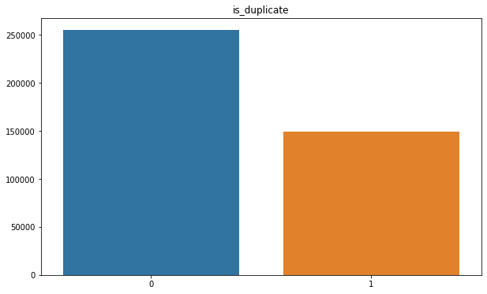

```python
## To print number of isDupicates count
print('The number of Question Pairs that are similar are : {}%'.format(round(sum(df['is_duplicate']==1)/len(df)*100,2)))
print('The number of Question Pairs that are not similar are : {}%'.format(round(100-sum(df['is_duplicate']==1)/len(df)*100,2)))

plt.figure(figsize=(10,6))
plt.title('is_duplicate')
sns.barplot([0,1],[sum(df['is_duplicate']==0),len(df)-sum(df['is_duplicate']==0)])
plt.show()
```

# Checking Duplicates

```python
## check whether group of questions are repeated

duplicate = df[['qid1','qid2','is_duplicate']].groupby(['qid1','qid2']).count()

## No of rows in group - No of rows in data set
print('No of Duplicate entries are : ' ,duplicate.shape[0]-df.shape[0])
```

```
No of Duplicate entries are :  0
```

# Occurence of Each Question

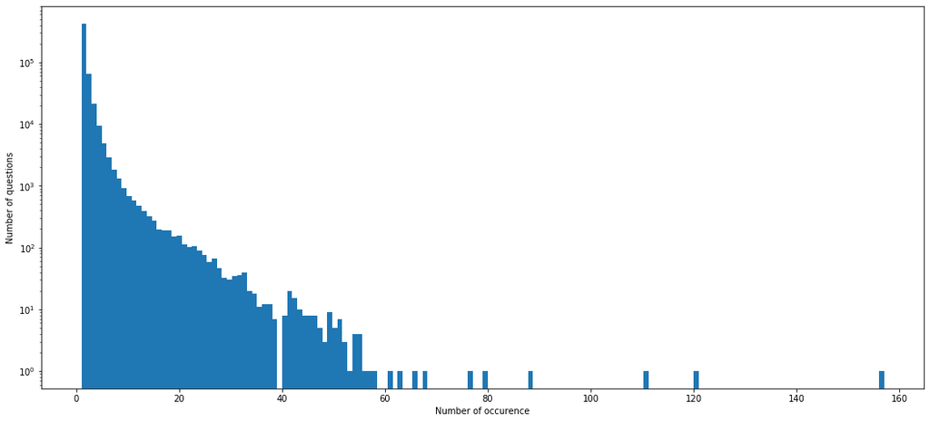

```python
plt.figure(figsize=(18,8))

plt.hist(Allques.value_counts(),bins=160)

plt.yscale('log',nonposy='clip')

plt.xlabel('Number of occurence')

plt.ylabel('Number of questions')
```

# Checking Null data set

```python
#Checking whether there are any rows with null values
nan_entry = df[df.isnull().any(1)]
print (nan_entry)

# As the entries are null we will drop
df = df.fillna(' ')

df.info()
```

```
            id    qid1    qid2                         question1  \
105780  105780  174363  174364    How can I develop android app?
201841  201841  303951  174364  How can I create an Android app?
363362  363362  493340  493341                               NaN

                                                question2  is_duplicate
105780                                                NaN             0
201841                                                NaN             0
363362  My Chinese name is Haichao Yu. What English na...             0
<class 'pandas.core.frame.DataFrame'>
RangeIndex: 404290 entries, 0 to 404289
Data columns (total 6 columns):
id              404290 non-null int64
qid1            404290 non-null int64
qid2            404290 non-null int64
question1       404290 non-null object
question2       404290 non-null object
is_duplicate    404290 non-null int64
dtypes: int64(4), object(2)
memory usage: 18.5+ MB
```

# Feature Extraction

- **freq_qid1** = Frequency of qid1's
- **freq_qid2** = Frequency of qid2's
- **q1len** = Length of q1
- **q2len** = Length of q2
- **q1_n_words** = Number of words in Question 1
- **q2_n_words** = Number of words in Question 2
- **word_Common** = (Number of common unique words in Question 1 and Question 2)
- **word_Total** =(Total num of words in Question 1 + Total num of words in Question 2)
- **word_share** = (word_common)/(word_Total)
- **freq_q1+freq_q2** = sum total of frequency of qid1 and qid2
- **freq_q1-freq_q2** = absolute difference of frequency of qid1 and qid2

# Calculating Values

```python
if os.path.isfile("df_features_train.csv"):
    df = pd.read_csv("df_features_train.csv",encoding='latin-1')
else:
    df['freq_qid1'] = df.groupby('qid1')['qid1'].transform('count')
    df['freq_qid2'] = df.groupby('qid2')['qid2'].transform('count')
    df['q1_len'] = df['question1'].str.len()
    df['q2_len'] = df['question2'].str.len()

    df['q1_n_words'] = df['question1'].apply(lambda row: len(row.split(" ")))
    df['q2_n_words'] = df['question2'].apply(lambda row: len(row.split(" ")))

    def word_common(row):
        w1 = set(map(lambda word : word.lower().strip(),row['question1'].split(' ')))
        w2 = set(map(lambda word : word.lower().strip(),row['question2'].split(' ')))
        return 1.0 * len(w1&w2)
    df['word_common'] = df.apply(word_common,axis = 1)

    def word_total(row):
        w1 = set(map(lambda word : word.lower().strip(),row['question1'].split(' ')))
        w2 = set(map(lambda word : word.lower().strip(),row['question2'].split(' ')))
        return 1.0 * (len(w1) + len(w2))
    df['word_total'] = df.apply(word_total,axis=1)

    def word_share(row):
        w1 = set(map(lambda word : word.lower().strip(),row['question1'].split(' ')))
        w2 = set(map(lambda word : word.lower().strip(),row['question2'].split(' ')))
        return 1.0*( len(w1 & w2)/(len(w1)+len(w2)))
    df['word_share'] = df.apply(word_share,axis=1)

    df['freq_q1+freq_q2'] = df['freq_qid1'] + df['freq_qid2']
    df['freq_q1-freq_q2'] = abs(df['freq_qid1'] - df['freq_qid2'])

    df.to_csv('df_features_train.csv',index='False')

df.head()
```

|  | id | qid1 | qid2 | question1 | question2 | is_duplicate | freq_qid1 | freq_qid2 | q1_len | q2_len | q1_n_words | q2_n_words | word_common | word_total | word_share | freq_q1+freq_q2 | freq_q1-freq_q2 |
| --- | --- | --- | --- | --- | --- | --- | --- | --- | --- | --- | --- | --- | --- | --- | --- | --- | --- |
| 0 | 0 | 1 | 2 | What is the step by step guide to invest in sh... | What is the step by step guide to invest in sh... | 0 | 1 | 1 | 66 | 57 | 14 | 12 | 10.0 | 23.0 | 0.434783 | 2 | 0 |
| 1 | 1 | 3 | 4 | What is the story of Kohinoor (Koh-i-Noor) Dia... | What would happen if the Indian government sto... | 0 | 4 | 1 | 51 | 88 | 8 | 13 | 4.0 | 20.0 | 0.200000 | 5 | 3 |
| 2 | 2 | 5 | 6 | How can I increase the speed of my internet co... | How can Internet speed be increased by hacking... | 0 | 1 | 1 | 73 | 59 | 14 | 10 | 4.0 | 24.0 | 0.166667 | 2 | 0 |
| 3 | 3 | 7 | 8 | Why am I mentally very lonely? How can I solve... | Find the remainder when [math]23^{24}[/math] i... | 0 | 1 | 1 | 50 | 65 | 11 | 9 | 0.0 | 19.0 | 0.000000 | 2 | 0 |
| 4 | 4 | 9 | 10 | Which one dissolve in water quikly sugar, salt... | Which fish would survive in salt water? | 0 | 3 | 1 | 76 | 39 | 13 | 7 | 2.0 | 20.0 | 0.100000 | 4 | 2 |

```python
df.head()
```

[output not shown]

# Plotting Word Share and Word Count

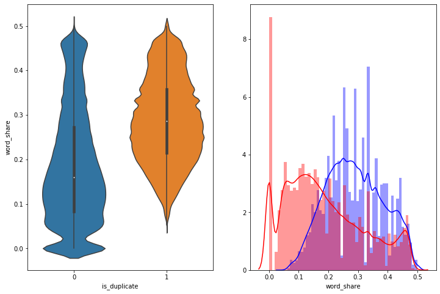

```python
plt.figure(figsize=(12, 8))

plt.subplot(1,2,1)
sns.violinplot(x='is_duplicate', y ='word_share',data=df)

plt.subplot(1,2,2)
sns.distplot(df[df['is_duplicate']==1]['word_share'][0:],label='1',color='blue')
sns.distplot(df[df['is_duplicate']==0]['word_share'][0:],label='0',color='red')
plt.show()
```

## The word share feature provides understanding with some overlapping....

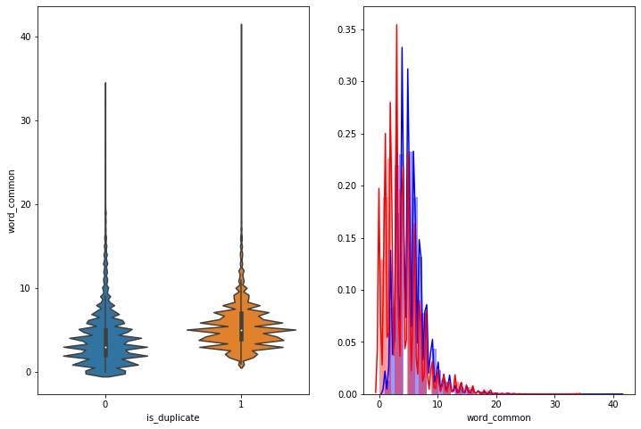

```python
plt.figure(figsize=(12, 8))

plt.subplot(1,2,1)
sns.violinplot(x='is_duplicate', y ='word_common',data=df)

plt.subplot(1,2,2)
sns.distplot(df[df['is_duplicate']==1]['word_common'][0:],label='1',color='blue')
sns.distplot(df[df['is_duplicate']==0]['word_common'][0:],label='0',color='red')
plt.show()
```

## The highly overlapped common_word feature doesn't provide any understanding.

## First Word Common

```python
# first word
def word_first(row):
        w1 = row['question1'].split(' ')[0].lower()
        w2 = row['question2'].split(' ')[0].lower()
        return w1,w2,w1==w2
tup = (df.apply(word_first,axis=1))
```

[output not shown]

[output not shown]

[output not shown]

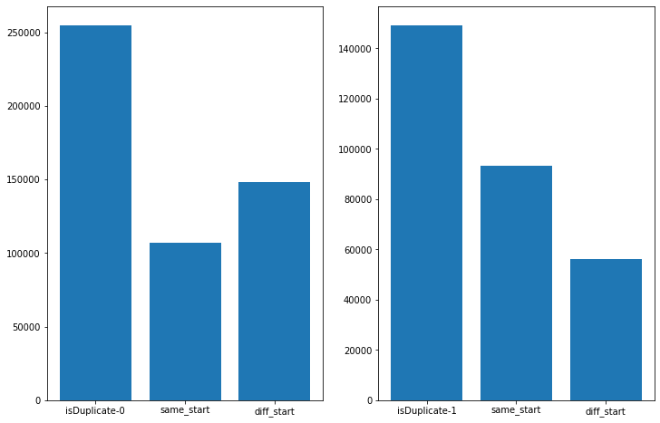

```python
ques1_start = []
ques2_start = []
isTrue = []
for val in tup:
    a,b,c = val
    ques1_start.append(a);
    ques2_start.append(b);
    isTrue.append(c);
count = 0
start_with_same = isTrue.count(True)
start_with_different = isTrue.count(False)

(print("Total number of questions starting with same word : ", start_with_same))
print("Total number of questions starting with different word : ", start_with_different)
print("The words starting with same word and are duplicate " ,len(df[isTrue][df['is_duplicate']==1]))
print("The words starting with same word and are not duplicate " ,len(df[isTrue][df['is_duplicate']==0]))
isFalse = [not c for c in isTrue]

print("The words starting with different word and are duplicate " ,len(df[isFalse][df['is_duplicate']==1]))
print("The words starting with different word and are not duplicate " ,len(df[isFalse][df['is_duplicate']==0]))

plt.figure(figsize=(12, 8))
plt.subplot(1,2,2)
plt.bar(x = ['isDuplicate-1','same_start','diff_start'], height = [len(df[df['is_duplicate']==1]),len(df[isTrue][df['is_duplicate']==1]),len(df[isFalse][df['is_duplicate']==1])])
plt.subplot(1,2,1)
plt.bar(x = ['isDuplicate-0','same_start','diff_start'], height = [len(df[df['is_duplicate']==0]),len(df[isTrue][df['is_duplicate']==0]),len(df[isFalse][df['is_duplicate']==0])])

plt.show()
```

```python
STOP_WORDS = stopwords.words("english") # is // the // very  // not  // to
def preprocess(x):
    x = str(x).lower()
    #stack exch
    x = x.replace(",000,000", "m").replace(",000", "k").replace("′", "'").replace("’", "'")\
                           .replace("won't", "will not").replace("cannot", "can not").replace("can't", "can not")\
                           .replace("n't", " not").replace("what's", "what is").replace("it's", "it is")\
                           .replace("'ve", " have").replace("i'm", "i am").replace("'re", " are")\
                           .replace("he's", "he is").replace("she's", "she is").replace("'s", " own")\
                           .replace("%", " percent ").replace("₹", " rupee ").replace("$", " dollar ")\
                           .replace("€", " euro ").replace("'ll", " will")

    # replacing millions 1m and thosands by 1k
    x = re.sub(r"([0-9]+)000000", r"\1m", x)

    x = re.sub(r"([0-9]+)000", r"\1k", x)


    porter = PorterStemmer()
    #######
    pattern = re.compile('\W')

    if type(x) == type(''):
        x = re.sub(pattern, ' ', x)
# beauti : beautiful
    if type(x) == type(''):
        x = porter.stem(x)
        soup = BeautifulSoup(x)
        x = soup.get_text()

    return x
```

Definition:

- **Token**: You get a token by splitting sentence a space
- **Stop_Word** : stop words as per NLTK.
- **Word** : A token that is not a stop_word

Features:

- **cwc_min** : Ratio of common_word_count to min lenghth of word count of Q1 and Q2  
  cwc_min = common_word_count / (min(len(q1_words), len(q2_words))
- **cwc_max** : Ratio of common_word_count to max lenghth of word count of Q1 and Q2  
  cwc_max = common_word_count / (max(len(q1_words), len(q2_words))
- **csc_min** : Ratio of common_stop_count to min lenghth of stop count of Q1 and Q2  
  csc_min = common_stop_count / (min(len(q1_stops), len(q2_stops))
- **csc_max** : Ratio of common_stop_count to max lenghth of stop count of Q1 and Q2  
  csc_max = common_stop_count / (max(len(q1_stops), len(q2_stops))
- **ctc_min** : Ratio of common_token_count to min lenghth of token count of Q1 and Q2  
  ctc_min = common_token_count / (min(len(q1_tokens), len(q2_tokens))
- **ctc_max** : Ratio of common_token_count to max lenghth of token count of Q1 and Q2  
  ctc_max = common_token_count / (max(len(q1_tokens), len(q2_tokens))
- **last_word_eq** : Check if Last word of both questions is equal or not  
  last_word_eq = int(q1_tokens[-1] == q2_tokens[-1])
- **first_word_eq** : Check if First word of both questions is equal or not  
  first_word_eq = int(q1_tokens[0] == q2_tokens[0])
- **abs_len_diff** : Abs. length difference  
  abs_len_diff = abs(len(q1_tokens) - len(q2_tokens))
- **mean_len** : Average Token Length of both Questions  
  mean_len = (len(q1_tokens) + len(q2_tokens))/2
- **fuzz_ratio** : https://github.com/seatgeek/fuzzywuzzy#usage http://chairnerd.seatgeek.com/fuzzywuzzy-fuzzy-string-matching-in-python/
- **fuzz_partial_ratio** : https://github.com/seatgeek/fuzzywuzzy#usage http://chairnerd.seatgeek.com/fuzzywuzzy-fuzzy-string-matching-in-python/
- **token_sort_ratio** : https://github.com/seatgeek/fuzzywuzzy#usage http://chairnerd.seatgeek.com/fuzzywuzzy-fuzzy-string-matching-in-python/
- **token_set_ratio** : https://github.com/seatgeek/fuzzywuzzy#usage http://chairnerd.seatgeek.com/fuzzywuzzy-fuzzy-string-matching-in-python/
- **longest_substr_ratio** : Ratio of length longest common substring to min lenghth of token count of Q1 and Q2  
  longest_substr_ratio = len(longest common substring) / (min(len(q1_tokens), len(q2_tokens))

```python
def get_features(q1,q2):
    # 10 list that will contain feature
    token_features = [0.0]*10
    SAFE_DIV = 0.0001
    # Converting the Sentence into Tokens:
    q1_tokens = q1.split()
    q2_tokens = q2.split()
# FUZZY - SIMILAR
    # Q1 NEW YORK MEaTs    fuzzy ratio good
    # Q2 NEW YORK MEATS
    #dISTANCE FEATURE /// EDITS Fuzzy ratio
    # NO OF EDITS GOOD FUZZY RATIO
    #  0-100
    # Similar to string matching problem learned in dynamic programming
    # string 1 YANKEES , NEW YORK YANKEES
    # string 2 NEWYORK METS NEW YORK YANKEES
    # fuuzz partial ratio # substring matches
    # token sort ..
    # "csk vs rcb"
    # "rcb vs csk"   partial ratio ...
    # csk , vs , rcb # sort
    # csk vs rcb  # 80 - 90  3
    # csk vs rcb , had a great match today and ............  200
    # token set ratio
    #t1 = [sorted intersection]
    # t2 = ..... + remaining s1  ->''
    # t3 = ...... + remaining of s2 -> 'had a great match.......'
    # t1 , t2 , t3 ratio similarity .....
    if len(q1_tokens) == 0 or len(q2_tokens) == 0:
        return token_features
    # Get the non-stopwords in Questions
    q1_words = set([word for word in q1_tokens if word not in STOP_WORDS])
    q2_words = set([word for word in q2_tokens if word not in STOP_WORDS])

    #Get the stopwords in Questions
    q1_stops = set([word for word in q1_tokens if word in STOP_WORDS])
    q2_stops = set([word for word in q2_tokens if word in STOP_WORDS])

    # Get the common non-stopwords from Question pair
    common_word_count = len(q1_words.intersection(q2_words))

    # Get the common stopwords from Question pair
    common_stop_count = len(q1_stops.intersection(q2_stops))

    # Get the common Tokens from Question pair
    common_token_count = len(set(q1_tokens).intersection(set(q2_tokens)))


    token_features[0] = common_word_count / (min(len(q1_words), len(q2_words)) + SAFE_DIV)
    token_features[1] = common_word_count / (max(len(q1_words), len(q2_words)) + SAFE_DIV)
    token_features[2] = common_stop_count / (min(len(q1_stops), len(q2_stops)) + SAFE_DIV)
    token_features[3] = common_stop_count / (max(len(q1_stops), len(q2_stops)) + SAFE_DIV)
    token_features[4] = common_token_count / (min(len(q1_tokens), len(q2_tokens)) + SAFE_DIV)
    token_features[5] = common_token_count / (max(len(q1_tokens), len(q2_tokens)) + SAFE_DIV)

    # Last word of both question is same or not
    token_features[6] = int(q1_tokens[-1] == q2_tokens[-1])

    # First word of both question is same or not
    token_features[7] = int(q1_tokens[0] == q2_tokens[0])

    token_features[8] = abs(len(q1_tokens) - len(q2_tokens))

    #Average Token Length of both Questions
    token_features[9] = (len(q1_tokens) + len(q2_tokens))/2
    return token_features


def get_longest_substr_ratio(a,b):
    strs = list(distance.lcsubstrings(a,b))
    if(len(strs)==0):
        return 0
    else:
        return len(strs[0]) / (min(len(a),len(b))+1)

def extract_features(df):
    # preprocessing
    df["question1"] = df["question1"].fillna("").apply(preprocess)
    df["question2"] = df["question2"].fillna("").apply(preprocess)

    print("token features")

    token_feature = df.apply((lambda x: get_features(x["question1"],x["question2"])),axis=1)

    df['cwc_min'] = list(map(lambda x : x[0], token_feature))
    df['cwc_max'] = list(map(lambda x : x[1], token_feature))
    df['csc_min'] = list(map(lambda x : x[2], token_feature))
    df['csc_max'] = list(map(lambda x : x[3], token_feature))
    df['ctc_min'] = list(map(lambda x : x[4], token_feature))
    df['ctc_max'] = list(map(lambda x : x[5], token_feature))
    df['last_word_eq'] = list(map(lambda x : x[6], token_feature))
    df['first_word_eq'] = list(map(lambda x : x[7], token_feature))
    df['abs_len_diff'] = list(map(lambda x: x[8] , token_feature))
    df['mean_len'] =  list(map(lambda x : x[7], token_feature))

    print("fuzzy features..")

    df["token_set_ratio"]       = df.apply(lambda x: fuzz.token_set_ratio(x["question1"], x["question2"]), axis=1)
    # The token sort approach involves tokenizing the string in question, sorting the tokens alphabetically, and
    # then joining them back into a string We then compare the transformed strings with a simple ratio().
    df["token_sort_ratio"]      = df.apply(lambda x: fuzz.token_sort_ratio(x["question1"], x["question2"]), axis=1)
    df["fuzz_ratio"]            = df.apply(lambda x: fuzz.QRatio(x["question1"], x["question2"]), axis=1)
    df["fuzz_partial_ratio"]    = df.apply(lambda x: fuzz.partial_ratio(x["question1"], x["question2"]), axis=1)
    df["longest_substr_ratio"]  = df.apply(lambda x: get_longest_substr_ratio(x["question1"], x["question2"]), axis=1)
    return df
```

```python
if os.path.isfile('minor/Files/nlp_features_train.csv'):
    df = pd.read_csv("minor/Files/nlp_features_train.csv",encoding='latin-1')
    df.fillna('')
else:
    print("Extracting features for train:")
    df = pd.read_csv("minor/DataSet/Quora.csv")
    df = extract_features(df)
    df.to_csv("nlp_features_train.csv", index=False)
df.head(2)
```

```
Extracting features for train:
token features
fuzzy features..
```

|  | id | qid1 | qid2 | question1 | question2 | is_duplicate | cwc_min | cwc_max | csc_min | csc_max | ... | ctc_max | last_word_eq | first_word_eq | abs_len_diff | mean_len | token_set_ratio | token_sort_ratio | fuzz_ratio | fuzz_partial_ratio | longest_substr_ratio |
| --- | --- | --- | --- | --- | --- | --- | --- | --- | --- | --- | --- | --- | --- | --- | --- | --- | --- | --- | --- | --- | --- |
| 0 | 0 | 1 | 2 | what is the step by step guide to invest in sh... | what is the step by step guide to invest in sh... | 0 | 0.999980 | 0.833319 | 0.999983 | 0.999983 | ... | 0.785709 | 0.0 | 1.0 | 2.0 | 1.0 | 100 | 93 | 93 | 100 | 0.982759 |
| 1 | 1 | 3 | 4 | what is the story of kohinoor koh i noor dia... | what would happen if the indian government sto... | 0 | 0.799984 | 0.399996 | 0.749981 | 0.599988 | ... | 0.466664 | 0.0 | 1.0 | 5.0 | 1.0 | 86 | 63 | 66 | 75 | 0.596154 |

2 rows × 21 columns

```python
# random forest logistic linear xg boost decision tree
```

```python
# spacy nlp spacy 100 d
```